# Week 4-HW

Raul Miranda

Oct. 19, 2025

### Homework Assignment: Analyzing NYC Flight Data

This homework assignment uses the `flights` dataset from the `nycflights13` package, which contains real-world data on over 336,000 flights departing from New York City airports (JFK, LGA, EWR) in 2013. The dataset includes variables such as departure and arrival times (with date components), airline carrier (categorical), origin and destination airports (categorical), delays (with missing values for cancelled flights), distance, and more. It is sourced from the US Bureau of Transportation Statistics.

#### Objectives

This assignment reinforces the Week 4 topics:

- Parsing and manipulating dates/times using `lubridate`.
- Creating and analyzing time series with `zoo`.
- Working with factors, inspecting levels, and recoding them.
- Identifying and handling missing data (e.g., removal, imputation).

All questions (except the final reflection) require you to write and run R code to solve them. Submit your URL for your RPubs. Make sure to comment your code, along with key outputs (e.g., summaries, plots, or tables). Use the provided setup code to load the data.

#### Setup

Install and load the necessary packages if not already done:

```r
#install.packages(c("tidyverse", nycflights13", "dplyr", "lubridate", "zoo", "forcats"))
library(tidyverse)
library(nycflights13)
library(dplyr)
library(lubridate)
library(zoo)
library(forcats)  # For factor recoding; base R alternatives are acceptable
data(flights)  # Load the dataset
```

Explore the data briefly with `str(flights)` and `head(flights)` to understand the structure. Note: Dates are in separate `year`, `month`, `day` columns; times are istr(flights)n `dep_time` and `arr_time` (as integers like 517 for 5:17 AM).

```r
#Explore your data here
str(flights)
```

```
## tibble [336,776 × 19] (S3: tbl_df/tbl/data.frame)
##  $ year          : int [1:336776] 2013 2013 2013 2013 2013 2013 2013 2013 2013 2013 ...
##  $ month         : int [1:336776] 1 1 1 1 1 1 1 1 1 1 ...
##  $ day           : int [1:336776] 1 1 1 1 1 1 1 1 1 1 ...
##  $ dep_time      : int [1:336776] 517 533 542 544 554 554 555 557 557 558 ...
##  $ sched_dep_time: int [1:336776] 515 529 540 545 600 558 600 600 600 600 ...
##  $ dep_delay     : num [1:336776] 2 4 2 -1 -6 -4 -5 -3 -3 -2 ...
##  $ arr_time      : int [1:336776] 830 850 923 1004 812 740 913 709 838 753 ...
##  $ sched_arr_time: int [1:336776] 819 830 850 1022 837 728 854 723 846 745 ...
##  $ arr_delay     : num [1:336776] 11 20 33 -18 -25 12 19 -14 -8 8 ...
##  $ carrier       : chr [1:336776] "UA" "UA" "AA" "B6" ...
##  $ flight        : int [1:336776] 1545 1714 1141 725 461 1696 507 5708 79 301 ...
##  $ tailnum       : chr [1:336776] "N14228" "N24211" "N619AA" "N804JB" ...
##  $ origin        : chr [1:336776] "EWR" "LGA" "JFK" "JFK" ...
##  $ dest          : chr [1:336776] "IAH" "IAH" "MIA" "BQN" ...
##  $ air_time      : num [1:336776] 227 227 160 183 116 150 158 53 140 138 ...
##  $ distance      : num [1:336776] 1400 1416 1089 1576 762 ...
##  $ hour          : num [1:336776] 5 5 5 5 6 5 6 6 6 6 ...
##  $ minute        : num [1:336776] 15 29 40 45 0 58 0 0 0 0 ...
##  $ time_hour     : POSIXct[1:336776], format: "2013-01-01 05:00:00" "2013-01-01 05:00:00" ...
```

```r
head(flights)
```

```
## # A tibble: 6 × 19
##    year month   day dep_time sched_dep_time dep_delay arr_time sched_arr_time
##   <int> <int> <int>    <int>          <int>     <dbl>    <int>          <int>
## 1  2013     1     1      517            515         2      830            819
## 2  2013     1     1      533            529         4      850            830
## 3  2013     1     1      542            540         2      923            850
## 4  2013     1     1      544            545        -1     1004           1022
## 5  2013     1     1      554            600        -6      812            837
## 6  2013     1     1      554            558        -4      740            728
## # ℹ 11 more variables: arr_delay <dbl>, carrier <chr>, flight <int>,
## #   tailnum <chr>, origin <chr>, dest <chr>, air_time <dbl>, distance <dbl>,
## #   hour <dbl>, minute <dbl>, time_hour <dttm>
```

#### Question 1: Creating Dates with `lubridate`

Create a column dep_datetime by combining year, month, day, and dep_time into a POSIXct datetime using lubridate. (Hint: Use `make_datetime` function to combine: year, month, day, for hour and min use division, e.g., hour = dep_time %/% 100, min = dep_time %% 100.)

Show the first 5 rows of flights with dep_datetime.

**Output:** First 5 rows showing year, month, day, dep_time, and dep_datetime.

```r
flights2 <- flights |>
mutate (dep_datetime = make_datetime(year, month, day, hour=dep_time %/% 100, min=dep_time %% 100))

select(flights2,year,month,day,dep_time,dep_datetime) |>
head(5)
```

```
## # A tibble: 5 × 5
##    year month   day dep_time dep_datetime
##   <int> <int> <int>    <int> <dttm>
## 1  2013     1     1      517 2013-01-01 05:17:00
## 2  2013     1     1      533 2013-01-01 05:33:00
## 3  2013     1     1      542 2013-01-01 05:42:00
## 4  2013     1     1      544 2013-01-01 05:44:00
## 5  2013     1     1      554 2013-01-01 05:54:00
```

#### Question 2: Simple Date Manipulations with `lubridate`

Using dep_datetime from Question 1, create a column weekday with the day of the week (e.g., “Mon”) using wday(dep_datetime, label = TRUE). Use table() to show how many flights occur on each weekday.

**Output:** The table of flight counts by weekday.

```r
flights_table <- flights2 |>
mutate ( weekday = wday(dep_datetime, label = TRUE))
table(flights_table$weekday)
```

```
##
##   Sun   Mon   Tue   Wed   Thu   Fri   Sat
## 45643 49468 49273 48858 48654 48703 37922
```

#### Question 3: Time Series with zoo

Filter for flights from JFK (origin == “JFK”) and create a zoo time series of departure delays (dep_delay) by dep_datetime. Plot the time series (use plot()). (Hint: Use a subset to avoid memory issues, e.g., first 1000 JFK flights using `slice_head().)

**Output:** The time series plot.

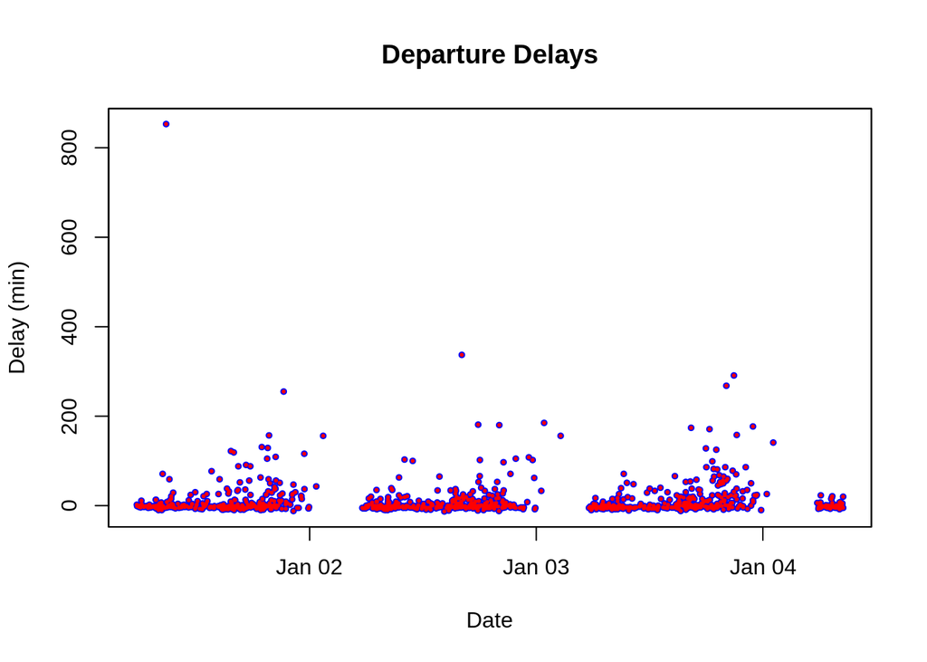

```r
flights3 <- flights2 |>
filter (origin == "JFK") |>
slice_head(n = 1000)                # flights3 contains just the first 1000 rows of the flights from JFK
zoo (flights3$dep_delay, flights3$dep_datetime) |>             # create the zoo time series and plot it
plot(main = "Departure Delays", xlab = "Date", ylab = "Delay (min)", type = "p", col="blue", pch=20, cex=0.8) |>
points(col = "red", pch = 20, cex = 0.4)
```

#### Question 4: Working with Factors

Convert the origin column (airports: “JFK”, “LGA”, “EWR”) to a factor called origin_factor. Show the factor levels with levels() and create a frequency table with table(). Make a bar plot of flights by airport using barplot().

**Output:** The levels, frequency table, and bar plot.

```r
flights2$origin_factor = factor(flights2$origin)      # convert to factor for table to work
levels(flights2$origin_factor)                        # show levels
```

```
## [1] "EWR" "JFK" "LGA"
```

```r
flights_by_airport <-table(flights2$origin_factor)    # create table
flights_by_airport                                    # show it
```

```
##
##    EWR    JFK    LGA
## 120835 111279 104662
```

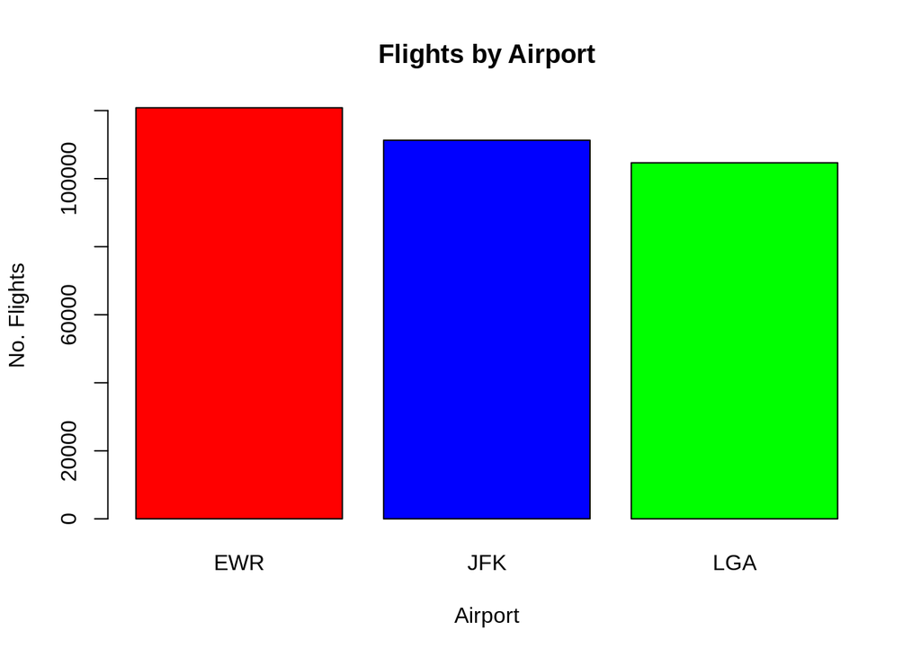

```r
barplot(flights_by_airport,                           # create barplot
  xlab = "Airport",
  ylab = "No. Flights",
  main = "Flights by Airport",
  col = c("red", "blue", "green")
)
```

#### Question 5: Recoding Factors

Recode origin_factor from Question 4 into a new column origin_recoded with full names: “JFK” to “Kennedy”, “LGA” to “LaGuardia”, “EWR” to “Newark” using fct_recode() or base R. Create a bar plot of the recoded factor.

**Output:** The new levels and bar plot.

```r
# recode using base-R

flights2$origin_recoded [flights2$origin_factor=="JFK"] <- "Kennedy"
```

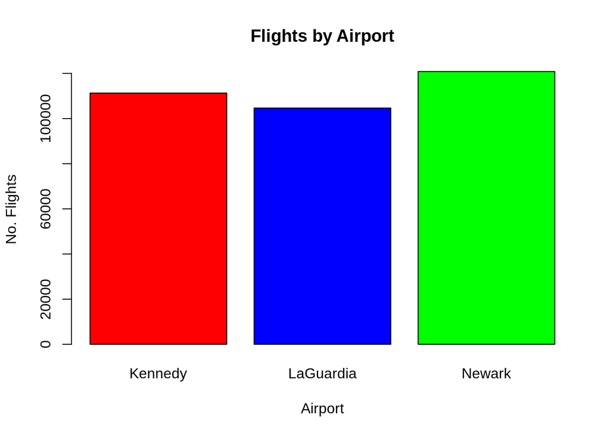

```r
flights2$origin_recoded [flights2$origin_factor=="LGA"] <- "LaGuardia"
flights2$origin_recoded [flights2$origin_factor=="EWR"] <- "Newark"
flights2$origin_recoded = factor(flights2$origin_recoded)      # convert to factor again for table to work
table(flights2$origin_recoded) |>
barplot(
  xlab = "Airport",
  ylab = "No. Flights",
  main = "Flights by Airport",
  col = c("red", "blue", "green")
)
```

```r
# try forcats fctrecode: have to use mutate to generate new column origin_recoded2. Yes it works since origin_recoded2=origin_recoded

  mutate ( flights2, origin_recoded2 = fct_recode (origin_factor, "Kennedy" = "JFK", "LaGuardia"="LGA", "Newark"="EWR"))
```

```
## # A tibble: 336,776 × 23
##     year month   day dep_time sched_dep_time dep_delay arr_time sched_arr_time
##    <int> <int> <int>    <int>          <int>     <dbl>    <int>          <int>
##  1  2013     1     1      517            515         2      830            819
##  2  2013     1     1      533            529         4      850            830
##  3  2013     1     1      542            540         2      923            850
##  4  2013     1     1      544            545        -1     1004           1022
##  5  2013     1     1      554            600        -6      812            837
##  6  2013     1     1      554            558        -4      740            728
##  7  2013     1     1      555            600        -5      913            854
##  8  2013     1     1      557            600        -3      709            723
##  9  2013     1     1      557            600        -3      838            846
## 10  2013     1     1      558            600        -2      753            745
## # ℹ 336,766 more rows
## # ℹ 15 more variables: arr_delay <dbl>, carrier <chr>, flight <int>,
## #   tailnum <chr>, origin <chr>, dest <chr>, air_time <dbl>, distance <dbl>,
## #   hour <dbl>, minute <dbl>, time_hour <dttm>, dep_datetime <dttm>,
## #   origin_factor <fct>, origin_recoded <fct>, origin_recoded2 <fct>
```